# POL2012: Theories and Models in Political Economy

Marius Swane Wishman

Department of Sociology and Political Science

## Inequality

## Inequality of what?

- Social
  $$\neq$$
  economic

  $$\neq$$
  income

  $$\neq$$
  wealth
- etc

## American Inequality

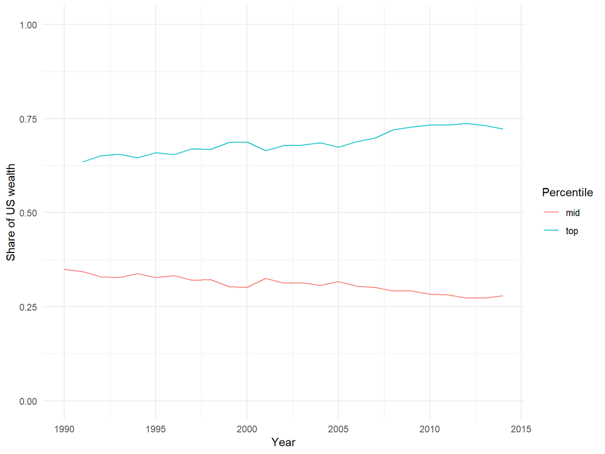

## Chinese Inequality

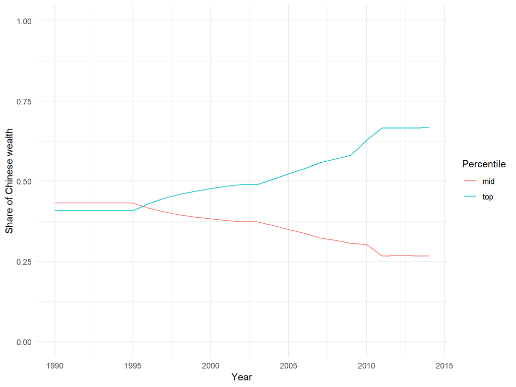

## Not a zero sum game!

#### Two broad trends lead to the same effect Every one is getting richer - some started with more The rich are getting richer faster than the rest

## What are the consequences?

- Decrease in economic growth?
- Social mobility?
  - From meritocracy to plutocracy?
- Protest parties and democratic degeneration
- Health?
- Riots? Revolution?
- Erodes social cohesion, reduces trust and legitimacy

## Causes?

[interactive chart not shown]

## Causes?

- Just a “natural” tendency?
- Globalization?
- Financial bubble?
- Politics?

## Politics

- Taxes until the late 1970s were much higher
- Race to the bottom?
- Manipulation of the financial system
  - Enabled by regulations lobbied for by the financial sector

## Response to Piketty

- Goes(2016): Observed increases in income inequality largely uncorrelated with changes in r > g.
- Acemoglu & Robinson (2015): Institutions!
  - r > g not unimportant (does lead to more inequality), but many other variables quantitatively more important
- Stiglitz: Two forms of capital

## Response from Piketty

- Institutions ARE important.
- r > g is important no matter what
- Data indicates that only wars and revolutions have mitigated wealth concentration.
- This is a problem no matter what!

## Soulutions?

[figure not shown]

## Soulutions?

- Progressive taxation
  - Public tax records?
- Global cooperation

## Soulutions?

[figure not shown]

[figure not shown]